# STATS 32: Introduction to R for Undergraduates

Elena Tuzhilina

Sep 23, 2021  
http://web.stanford.edu/~elenatuz/courses/stats32-aut2021/

# Recap: R as calculator

```r
3 + 4
```

```
## [1] 7
```

```r
exp(1)
```

```
## [1] 2.718282
```

```r
log(exp(1))
```

```
## [1] 1
```

```r
pi
```

```
## [1] 3.141593
```

```r
5.2 / 0
```

```
## [1] Inf
```

# Recap: Variables

- Types of variables in R
  - Numeric (e.g. 1, -3.5, 200)
  - Character/string (“abc”, “R”, “94305”)
  - Boolean/logical (`TRUE` or `FALSE`)
  - `NA`s
- Variable assignment

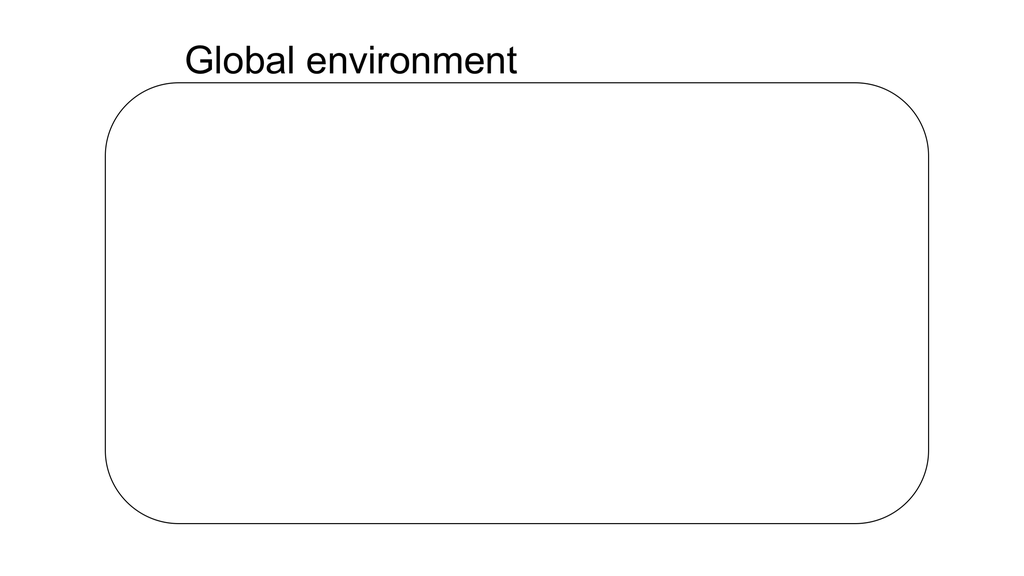

```r
x <- 3
```

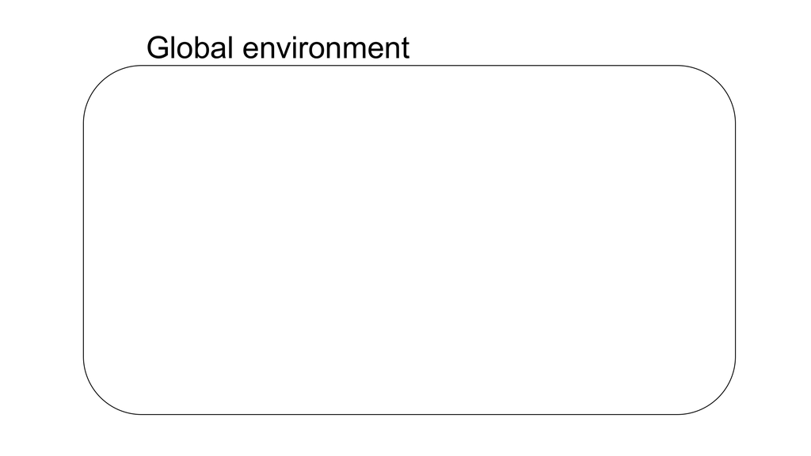

```r
x <- 3
```

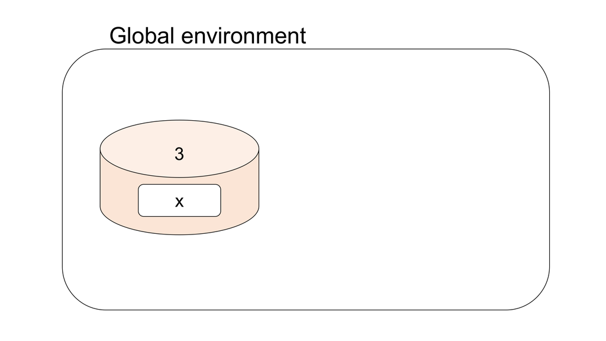

```r
x <- 3
y <- "abc"
```

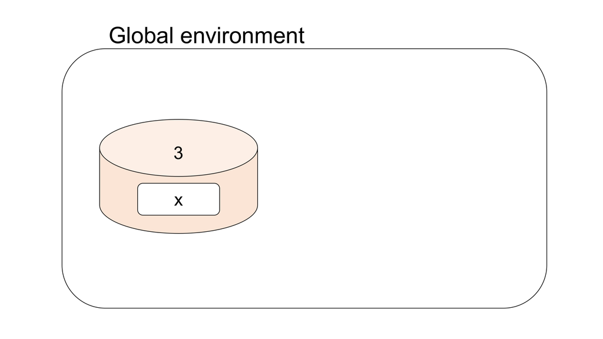

```r
x <- 3
y <- "abc"
```

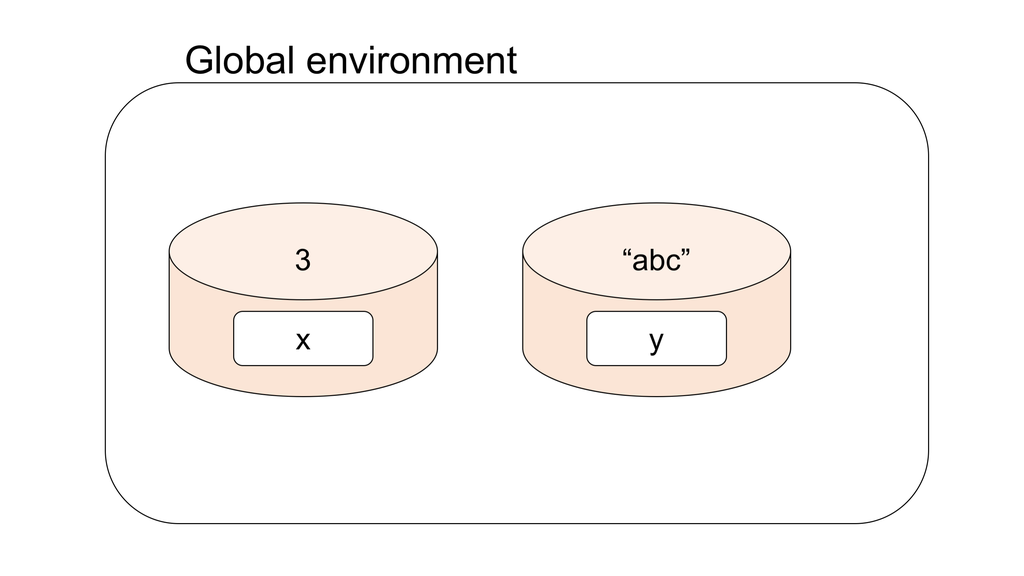

```r
x <- 3
y <- "abc"
y <- 5
```

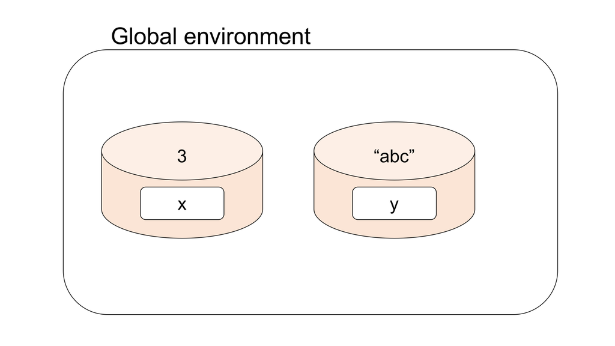

```r
x <- 3
y <- "abc"
y <- 5
```

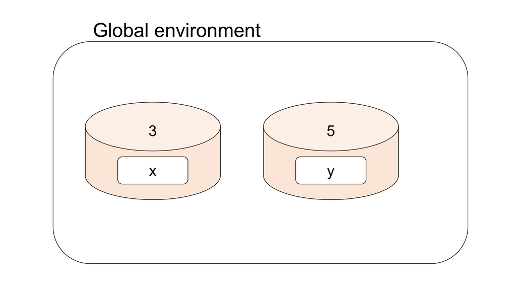

# Reminder!

- Install R, RStudio and the relevant R packages!
- Instructions on the course website under Session 1
- **Make sure you are using the latest versions!**

# Agenda for today

- Basic R objects
  - Vectors
  - Matrices/arrays
  - Lists
  - Data frames

# Vectors

- One-dimensional array whose entries are the same type
- Can be created using the `c()` function, or using the `:` shortcut

```r
vec <- c("a", "b", "c")
vec
```

```
## [1] "a" "b" "c"
```

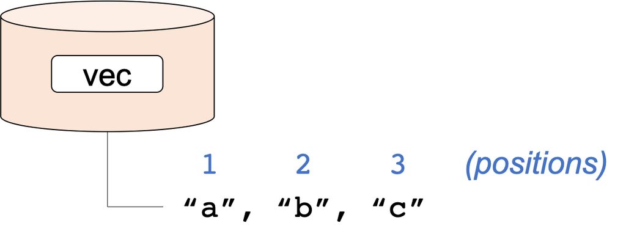

# Vectors

- One-dimensional array whose entries are the same type
- Can be created using the `c()` function, or using the `:` shortcut

```r
vec <- 1:100
vec
```

```
##   [1]   1   2   3   4   5   6   7   8   9  10  11  12  13  14  15  16  17  18
##  [19]  19  20  21  22  23  24  25  26  27  28  29  30  31  32  33  34  35  36
##  [37]  37  38  39  40  41  42  43  44  45  46  47  48  49  50  51  52  53  54
##  [55]  55  56  57  58  59  60  61  62  63  64  65  66  67  68  69  70  71  72
##  [73]  73  74  75  76  77  78  79  80  81  82  83  84  85  86  87  88  89  90
##  [91]  91  92  93  94  95  96  97  98  99 100
```

# Vectors

- We can manipulate vectors using arithmetic operations (just like numbers).
- Arithmetic operations happen element-wise.

```r
even <- 1:50 * 2
even
```

```
##  [1]   2   4   6   8  10  12  14  16  18  20  22  24  26  28  30  32  34  36  38
## [20]  40  42  44  46  48  50  52  54  56  58  60  62  64  66  68  70  72  74  76
## [39]  78  80  82  84  86  88  90  92  94  96  98 100
```

Alternatively, you can use `seq()` function.

```r
even <- seq(from = 2, to = 100, by = 2)
even
```

```
##  [1]   2   4   6   8  10  12  14  16  18  20  22  24  26  28  30  32  34  36  38
## [20]  40  42  44  46  48  50  52  54  56  58  60  62  64  66  68  70  72  74  76
## [39]  78  80  82  84  86  88  90  92  94  96  98 100
```

# Vectors

- We can manipulate vectors using arithmetic operations (just like numbers).
- Arithmetic operations happen element-wise.

```r
even
```

```
##  [1]   2   4   6   8  10  12  14  16  18  20  22  24  26  28  30  32  34  36  38
## [20]  40  42  44  46  48  50  52  54  56  58  60  62  64  66  68  70  72  74  76
## [39]  78  80  82  84  86  88  90  92  94  96  98 100
```

How can we get the odd numbers from 1 to 100 from `even`?

# Vectors

- We can manipulate vectors using arithmetic operations (just like numbers).
- Arithmetic operations happen element-wise.

```r
even
```

```
##  [1]   2   4   6   8  10  12  14  16  18  20  22  24  26  28  30  32  34  36  38
## [20]  40  42  44  46  48  50  52  54  56  58  60  62  64  66  68  70  72  74  76
## [39]  78  80  82  84  86  88  90  92  94  96  98 100
```

How can we get the odd numbers from 1 to 100 from `even`?

```r
odd <- even - 1
odd
```

```
##  [1]  1  3  5  7  9 11 13 15 17 19 21 23 25 27 29 31 33 35 37 39 41 43 45 47 49
## [26] 51 53 55 57 59 61 63 65 67 69 71 73 75 77 79 81 83 85 87 89 91 93 95 97 99
```

# Vectors

We can use the `c()` function to concatenate vectors.

```r
z <- 1:5
z <- c(z, 3, z)
z
```

```
##  [1] 1 2 3 4 5 3 1 2 3 4 5
```

# Vectors: Indexing

To extract a subset of elements by their indices, put a vector of indices in square brackets

```r
even
```

```
##  [1]   2   4   6   8  10  12  14  16  18  20  22  24  26  28  30  32  34  36  38
## [20]  40  42  44  46  48  50  52  54  56  58  60  62  64  66  68  70  72  74  76
## [39]  78  80  82  84  86  88  90  92  94  96  98 100
```

```r
even[1]
```

```
## [1] 2
```

# Vectors: Indexing

To extract a subset of elements by their indices, put a vector of indices in square brackets

```r
even
```

```
##  [1]   2   4   6   8  10  12  14  16  18  20  22  24  26  28  30  32  34  36  38
## [20]  40  42  44  46  48  50  52  54  56  58  60  62  64  66  68  70  72  74  76
## [39]  78  80  82  84  86  88  90  92  94  96  98 100
```

```r
even[3:7]
```

```
## [1]  6  8 10 12 14
```

# Vectors: Indexing

To extract a subset of elements by their indices, put a vector of indices in square brackets

```r
even
```

```
##  [1]   2   4   6   8  10  12  14  16  18  20  22  24  26  28  30  32  34  36  38
## [20]  40  42  44  46  48  50  52  54  56  58  60  62  64  66  68  70  72  74  76
## [39]  78  80  82  84  86  88  90  92  94  96  98 100
```

```r
even[c(3,5)]
```

```
## [1]  6 10
```

Note: `even[3,5]` will not work!

# Vectors: Negative indexing

To extract all except a few indices, put a negative sign before the vector of indices

```r
even
```

```
##  [1]   2   4   6   8  10  12  14  16  18  20  22  24  26  28  30  32  34  36  38
## [20]  40  42  44  46  48  50  52  54  56  58  60  62  64  66  68  70  72  74  76
## [39]  78  80  82  84  86  88  90  92  94  96  98 100
```

```r
even[-c(1,2)]
```

```
##  [1]   6   8  10  12  14  16  18  20  22  24  26  28  30  32  34  36  38  40  42
## [20]  44  46  48  50  52  54  56  58  60  62  64  66  68  70  72  74  76  78  80
## [39]  82  84  86  88  90  92  94  96  98 100
```

# Vectors: Length

Use the `length` function to figure out how many elements there are in a vector

```r
even
```

```
##  [1]   2   4   6   8  10  12  14  16  18  20  22  24  26  28  30  32  34  36  38
## [20]  40  42  44  46  48  50  52  54  56  58  60  62  64  66  68  70  72  74  76
## [39]  78  80  82  84  86  88  90  92  94  96  98 100
```

```r
length(even)
```

```
## [1] 50
```

# Vectors: Things to watch out for

What happens if we try to extract an invalid index?

```r
odd[0]
```

# Vectors: Things to watch out for

What happens if we try to extract an invalid index?

```r
odd[0]
```

```
## numeric(0)
```

**No error thrown!!**

# Vectors: Things to watch out for

What happens if we try to extract an invalid index?

```r
odd[0]
```

```
## numeric(0)
```

**No error thrown!!**

```r
odd[51]
```

# Vectors: Things to watch out for

What happens if we try to extract an invalid index?

```r
odd[0]
```

```
## numeric(0)
```

**No error thrown!!**

```r
odd[51]
```

```
## [1] NA
```

**No error thrown!!**

# Vectors: Things to watch out for

If we try to assign a vector with different types, **type coercion** happens.

```r
c(1, 2, "a")
```

```
## [1] "1" "2" "a"
```

# Matrices and arrays

Two-dimensional analogs of vectors

```r
A <- matrix(1:12, nrow = 3, ncol = 4)
A
```

```
##      [,1] [,2] [,3] [,4]
## [1,]    1    4    7   10
## [2,]    2    5    8   11
## [3,]    3    6    9   12
```

or you can omit one of the arguments

```r
A <- matrix(1:12, nrow = 3)
A
```

```
##      [,1] [,2] [,3] [,4]
## [1,]    1    4    7   10
## [2,]    2    5    8   11
## [3,]    3    6    9   12
```

# Matrices: Indexing

```r
A
```

```
##      [,1] [,2] [,3] [,4]
## [1,]    1    4    7   10
## [2,]    2    5    8   11
## [3,]    3    6    9   12
```

Indexing: put the rows you want before the comma, columns you want after the comma

```r
A[1, 2]
```

```
## [1] 4
```

What does `A[c(1,3), c(2,4)]` return?

# Matrices: Indexing example

```r
A
```

```
##      [,1] [,2] [,3] [,4]
## [1,]    1    4    7   10
## [2,]    2    5    8   11
## [3,]    3    6    9   12
```

What does `A[c(1,3), c(2,4)]` return?

```r
A[c(1,3), c(2,4)]
```

```
##      [,1] [,2]
## [1,]    4   10
## [2,]    6   12
```

# Lists

- A collection of key-value pairs
- Keys are character strings, values can be anything!
- Values do not have to be of the same type for different keys
- Created with the `list()` function

# List example

```r
cars <- list(make = "Honda",
             models = c("Fit", "CR-V", "Odyssey"),
             available = c(TRUE, TRUE, TRUE))
```

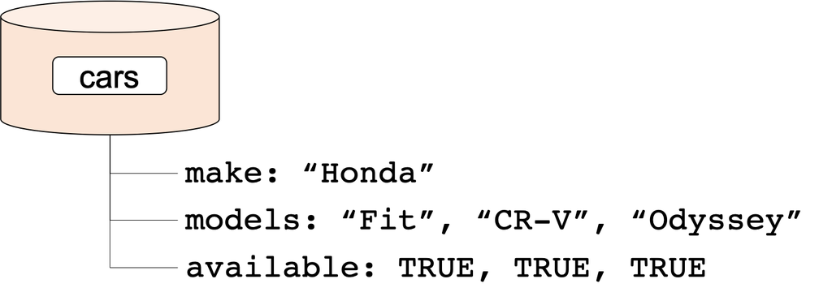

# Extracting parts of a list

Use `[[` or `$` notation to refer to a specific key-value pair

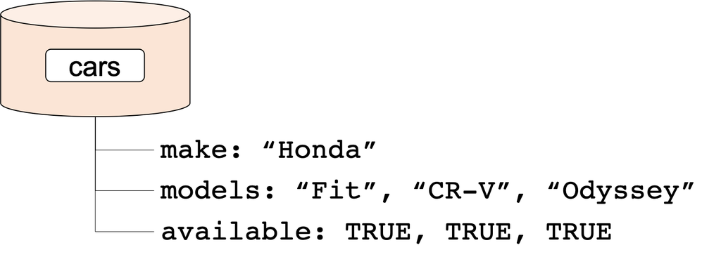

```r
cars$make         # no quotation marks
```

```
## [1] "Honda"
```

```r
cars[["models"]]  # remember quotation marks!
```

```
## [1] "Fit"     "CR-V"    "Odyssey"
```

# What is a data frame?

- A **data frame** is R’s data structure for storing datasets
  - First row: variable/covariate/feature names
  - Each subsequent row represents one observation
  - Each column contains the values of that variable across observations
- **Tibbles**: A data frame with some cosmetic changes

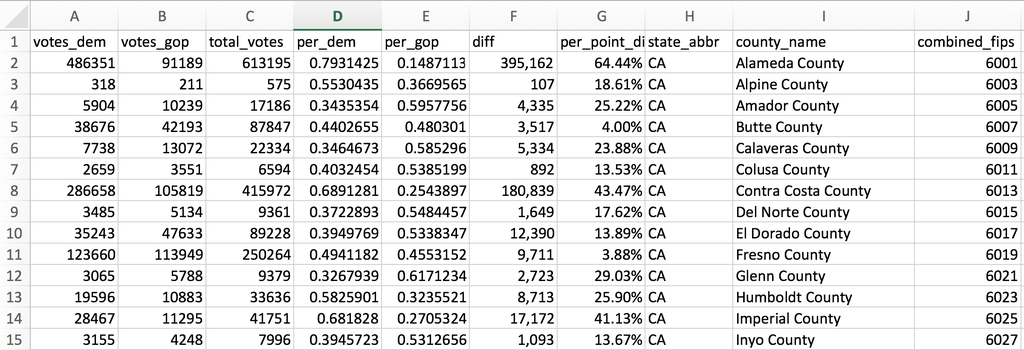

Example of a dataset

# Data frame/tibble printed to screen

```r
df
```

```
##   votes_dem votes_gop
## 1    486351     91189
## 2       318       211
## 3      5904     10239
```

```r
tbl
```

```
## # A tibble: 3 x 2
##   votes_dem votes_gop
##       <dbl>     <dbl>
## 1    486351     91189
## 2       318       211
## 3      5904     10239
```

# Structure of data frame

```r
str(df)
```

```
## 'data.frame':    3 obs. of  2 variables:
##  $ votes_dem: num  486351 318 5904
##  $ votes_gop: num  91189 211 10239
```

# Data frames “under the hood”

- To R, a data frame is simply a special type of list!
  - Keys of the list are the variable/covariate names
  - Values are vectors of the same length

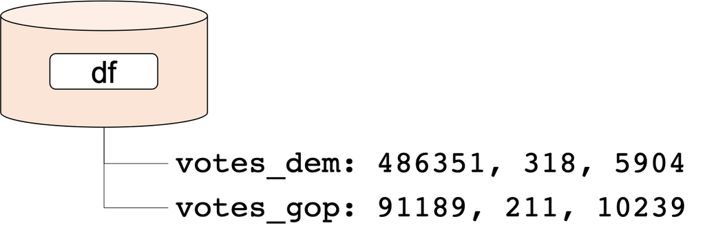

# Data frames “under the hood”

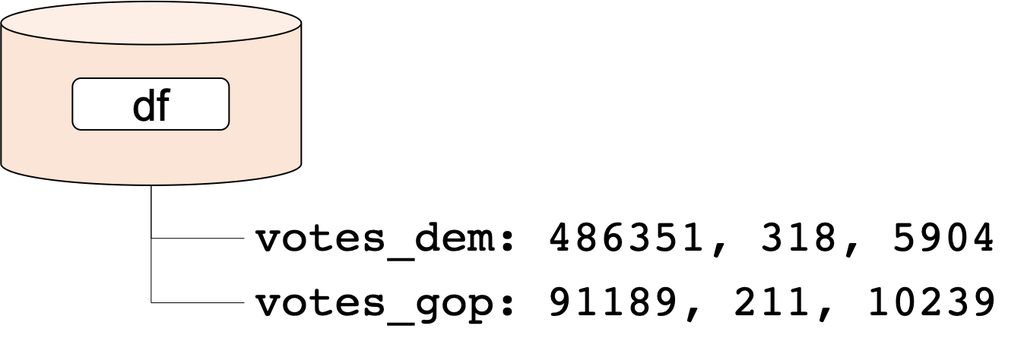

```r
is.list(df)
```

```
## [1] TRUE
```

```r
df$votes_dem
```

```
## [1] 486351    318   5904
```

# Today’s dataset: Fuel economy

[figure not shown]

(Source: [SuperCars](http://www.thesupercars.org/top-cars/most-fuel-efficient-sports-cars-top-10-list/))

# `fueleconomy`: Package information on [CRAN](https://cran.r-project.org/)

https://cran.r-project.org/web/packages/fueleconomy/index.html

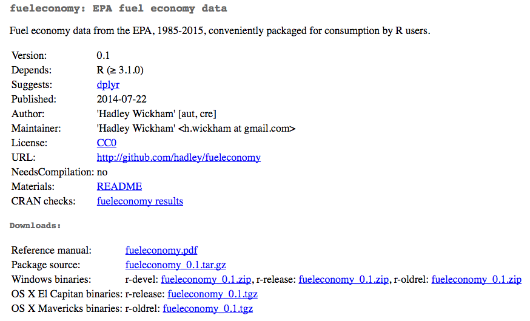

**Optional material**

# Measures of central tendency

- **Mean**: sum of all values divided by the number of values
- **Mode**: most commonly occuring value
- **$x$th percentile**: value such that $x$% of the values fall below it
  - **Median**: 50th percentile
  - **1st quartile**: 25th percentile
  - **3rd quartile**: 75th percentile

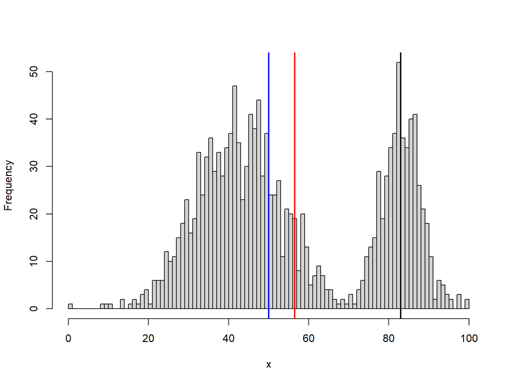

# Measures of spread

- **Variance**: average squared deviation from the mean
- **Standard deviation**: square root of variance
- **Interquartile range**: 3rd quartile - 1st quartile